# Homework 11

Alicja Dutkiewicz - s2530856

Irina Gurewitsch - s2621258

João Esteves - s2679663

01/12/2019

### Reusable code for the exercises

```r
# Layout and colors of graph (according to wikimedia example)
l <- matrix(c(
  2, 4, 0.5, 1.4,   5, 5, 4.5, 4, 3, 1.5, 3,
  5, 5.3, 4,   3.5, 4, 3, 3.5, 2.7, 2.2, 2, 3.5
), nrow=11)

smileycolors=c('yellow','red','green', 'red', 'green',
               'green','green','green','green','green',
               'turquoise')

init.graph <- function() {
    # Intitialize graph
  edge.list <- list(c(2, 1), c(1,2), c(4,1), c(4,3), c(5,1), c(11, 1),
                    c(11,4), c(11,5), c(5,11), c(6,11), c(7,11),
                    c(8,11), c(9,11), c(10, 11), c(10, 1), c(9, 1), c(8,1))

  A <- matrix(0, nrow = 11, ncol = 11)

  for(edge in edge.list) {
    A[edge[1], edge[2]] <- 1
  }


  return(A)
}

# Define function for iterative page rank update.
update.x <- function(x, alpha, beta) {
  out.degree <- rowSums(M)

  for (i in seq_along(x)) {
    tmp <- 0
    for (j in seq(1, nrow(M))) {
      if (i != j && M[j, i] != 0){
        tmp <- tmp + x[j] / out.degree[j]
      }
    }
    x[i] <- alpha * tmp + beta
  }

  return(x)
}

# Page rank algorithm. It was modified to only draw the graphs if so desired and added the option of drawing a convergence plot.
page.rank <- function(n.iter, alpha, M, G, draw.plot = FALSE, draw.convergence = FALSE) {
  beta <- (1 - alpha) / nrow(M)
  x <- rep(0, 11)
  x.diffs <- c()

  for (i in seq(n.iter)) {
    x.old <- x
    x <- update.x(x.old, alpha, beta)
    x.diffs[i] <- sqrt(sum((x-x.old)^2))
    if (draw.plot) {
      print(paste('iteration', i, x.diffs[i]))
      plot(G, vertex.size = x*5e2, vertex.color=smileycolors, layout=l)
    }
  }
  if (draw.convergence) {
    plot(1:n.iter, x.diffs, xlab = "Iterations")
  }
  return(x)
}
```

## Exercise 1

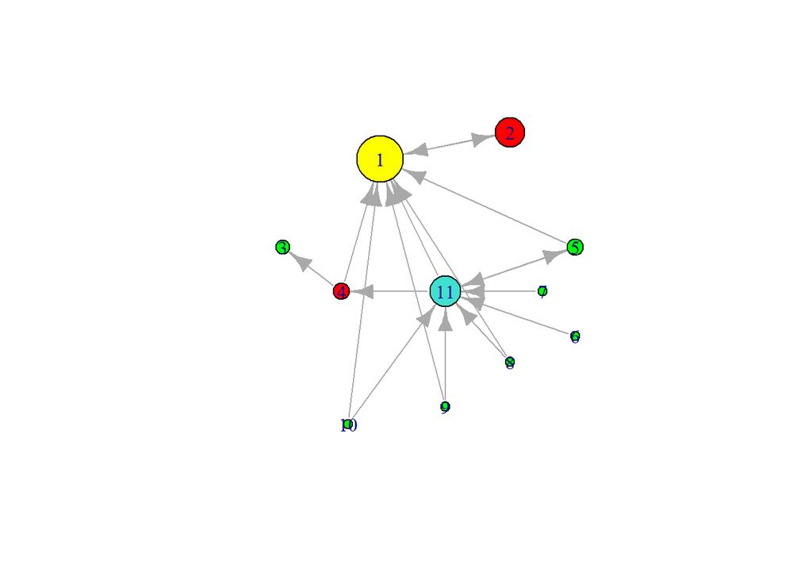

```r
A <- init.graph()
G <- graph.adjacency(A)
# Add self loops
M <- A + diag(rep(1, 11))

x <- page.rank(n.iter = 20, alpha = 0.85, M, G)
plot(G, vertex.size = x*5e2, vertex.color=smileycolors, layout=l)
```

## Exercise 2

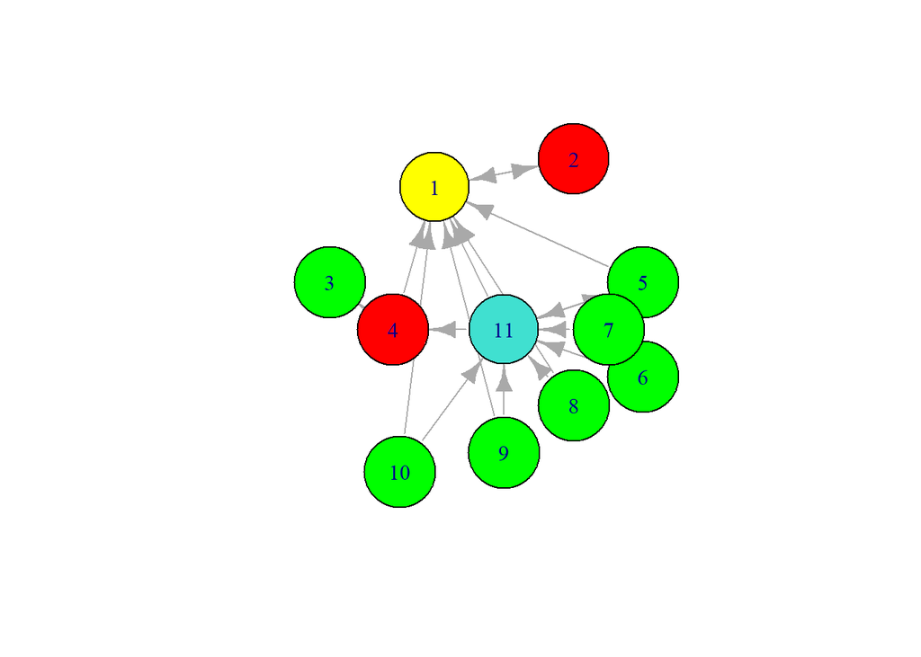

```r
A <- init.graph()
G <- graph.adjacency(A)
# Add self loops
M <- A + diag(rep(1, 11))

x <- page.rank(n.iter = 20, alpha = -0.01, M, G)
plot(G, vertex.size = x*5e2, vertex.color=smileycolors, layout=l)
```

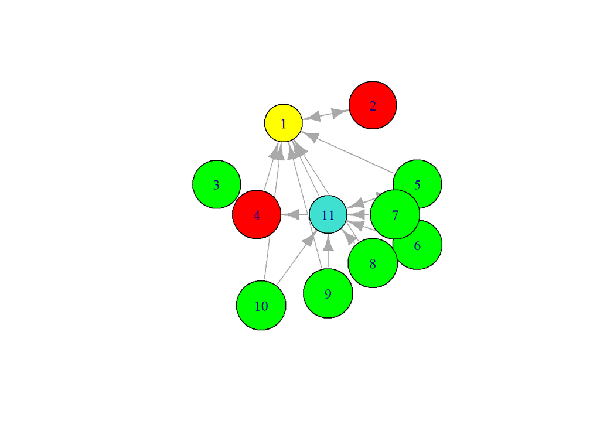

```r
x <- page.rank(n.iter = 20, alpha = -0.1, M, G)
plot(G, vertex.size = x*5e2, vertex.color=smileycolors, layout=l)
```

It can be seen in the first graph that having a negative alpha (-0.01) makes previously small nodes bigger, which means nodes with a small rank now obtain a higher rank. Decreasing the negative alpha further, as is the case in the second graph with alpha = -0.1, the same effect is observed with the oiginally small nodes growing even bigger but now it’s also observed that the originally big nodes get smaller, so what used to be the more important nodes are now lower ranked.

This means the algorithm is reversed, attributing a higher rank to less important nodes. This is explained by the fact that alpha is a factor applied to each node’s strength given by its neighbors, so a negative alpha will result in higher values for inferior neighbor strengths.

## Exercise 3

Below are shown page rank plots for alpha values of 0.9, 0.95, 0.98 and 1.

```
## [1] "alpha = 0.9"
##  [1] "x = 0.0472702518304091"  "x = 0.0303625224145932"
##  [3] "x = 0.0138581525712893"  "x = 0.0158908116012674"
##  [5] "x = 0.0158908116012674"  "x = 0.00909090909090909"
##  [7] "x = 0.00909090909090909" "x = 0.00909090909090909"
##  [9] "x = 0.00909090909090909" "x = 0.00909090909090909"
## [11] "x = 0.0302217889349257"
```

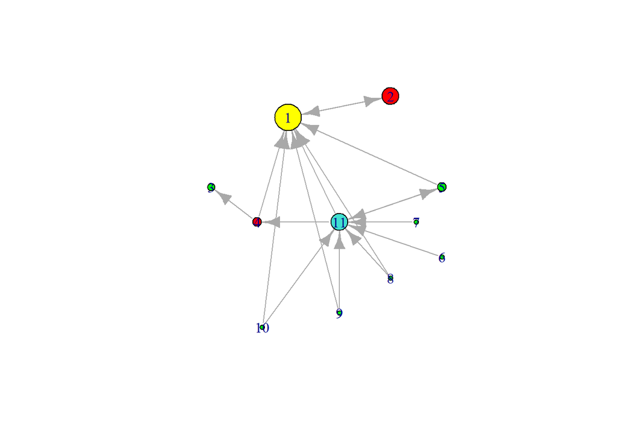

```
## [1] "alpha = 0.95"
##  [1] "x = 0.0258719418630786"  "x = 0.0168346269304169"
##  [3] "x = 0.00717391304347827" "x = 0.008300395256917"
##  [5] "x = 0.008300395256917"   "x = 0.00454545454545455"
##  [7] "x = 0.00454545454545455" "x = 0.00454545454545455"
##  [9] "x = 0.00454545454545455" "x = 0.00454545454545455"
## [11] "x = 0.0158102766798419"
```

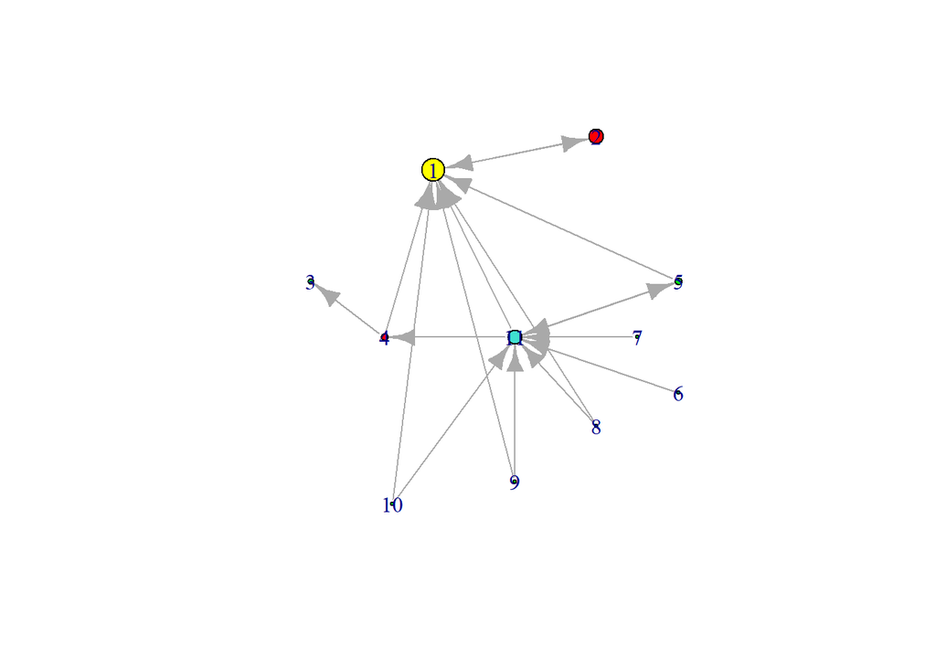

```
## [1] "alpha = 0.98"
##  [1] "x = 0.0109355818497924"  "x = 0.00717661692458009"
##  [3] "x = 0.00293198765436166" "x = 0.00340960970259134"
##  [5] "x = 0.00340960970259134" "x = 0.00181818181818182"
##  [7] "x = 0.00181818181818182" "x = 0.00181818181818182"
##  [9] "x = 0.00181818181818182" "x = 0.00181818181818182"
## [11] "x = 0.00649562401799802"
```

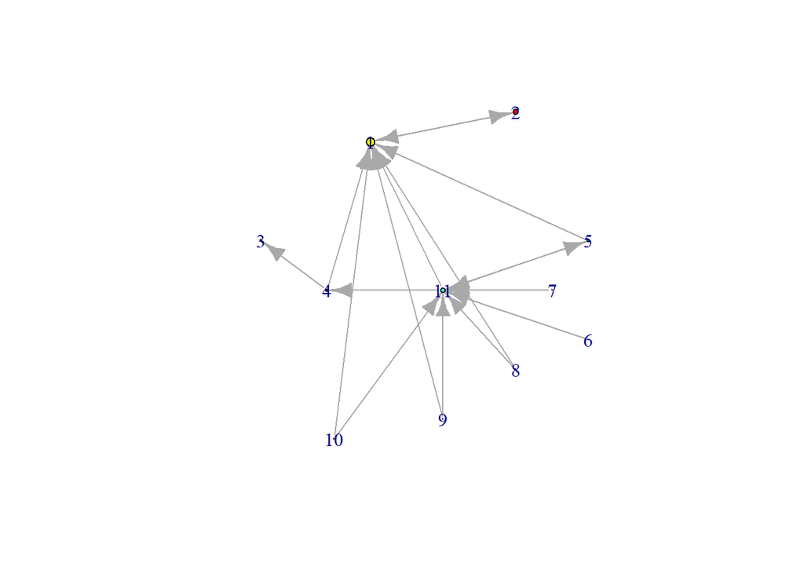

```
## [1] "alpha = 1"
##  [1] "x = 0" "x = 0" "x = 0" "x = 0" "x = 0" "x = 0" "x = 0" "x = 0"
##  [9] "x = 0" "x = 0" "x = 0"
```

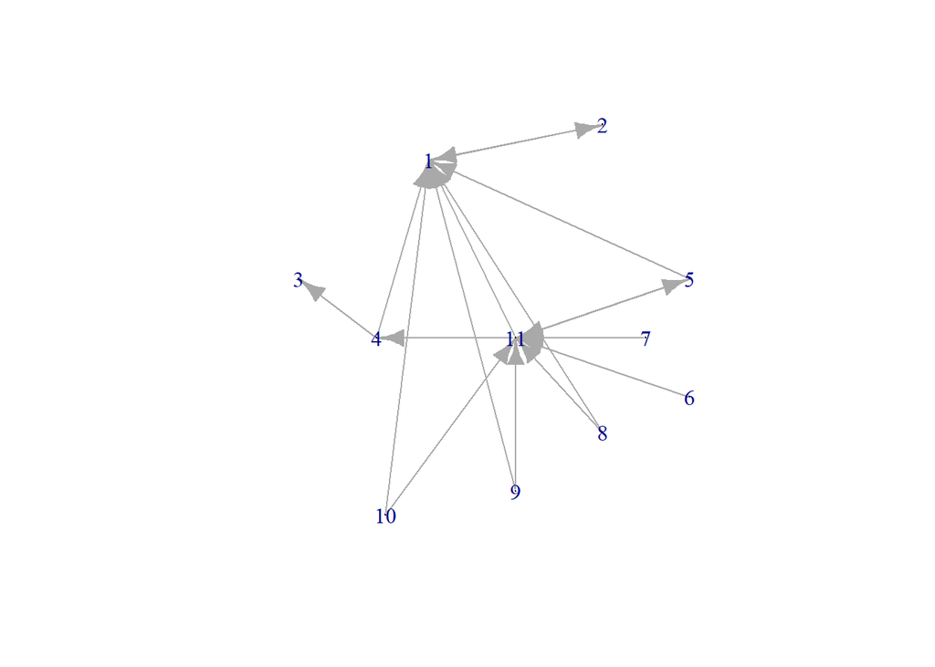

```r
A <- init.graph()
G <- graph.adjacency(A)
# Add self loops
M <- A + diag(rep(1, 11))

for (alpha in c(0.9, 0.95, 0.98, 1)) {
  x <- page.rank(n.iter = 20, alpha, M, G)
  print(paste('alpha =', alpha))
  print(paste('x =', x))
  plot(G, vertex.size = x*5e2, vertex.color=smileycolors, layout=l)
}
```

Page rank produces proper results for alpha values lower than 1. At alpha = 1, the nodes’ scores are all 0 and so the vertices do not appear in the plot because their sizes are also 0. This is because the initial score for each node is 0, and the only way to increase it when all the neighbors are also 0 is the (1 - alpha) / |V| parcel in the formula. When alpha = 1, this factor will be 0 and therefore the scores can’t increase. Furthermore, alpha > 1 would lead to invalid plots in this case because the scores would be negative.

It should be noted the transition around this boundary is smooth, with the nodes’ scores lowering gradually as alpha increases up to 1.

## Exercise 4

```
## [1] "alpha = 0.1"
```

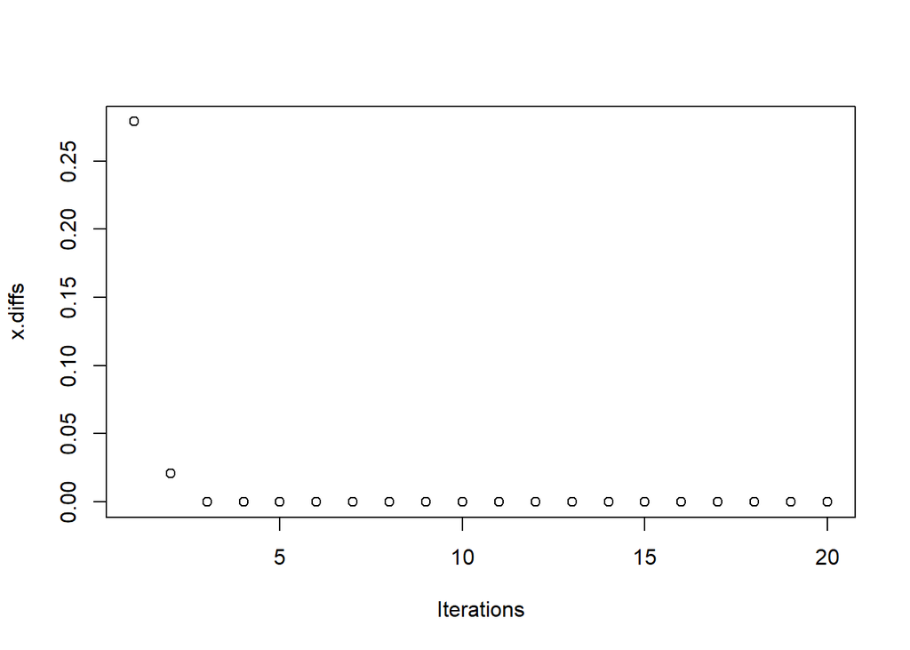

```
##  [1] 0.10249485 0.08694292 0.08462962 0.08434301 0.08434301 0.08181818
##  [7] 0.08181818 0.08181818 0.08181818 0.08181818 0.10099325
```

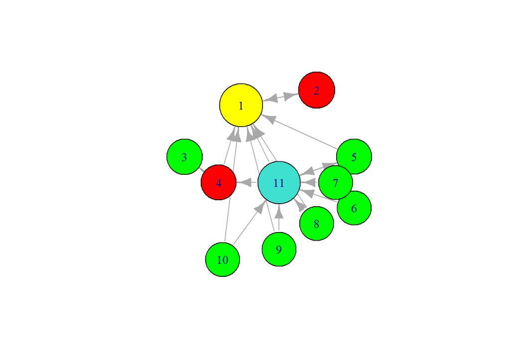

```
## [1] "alpha = 0.5"
```

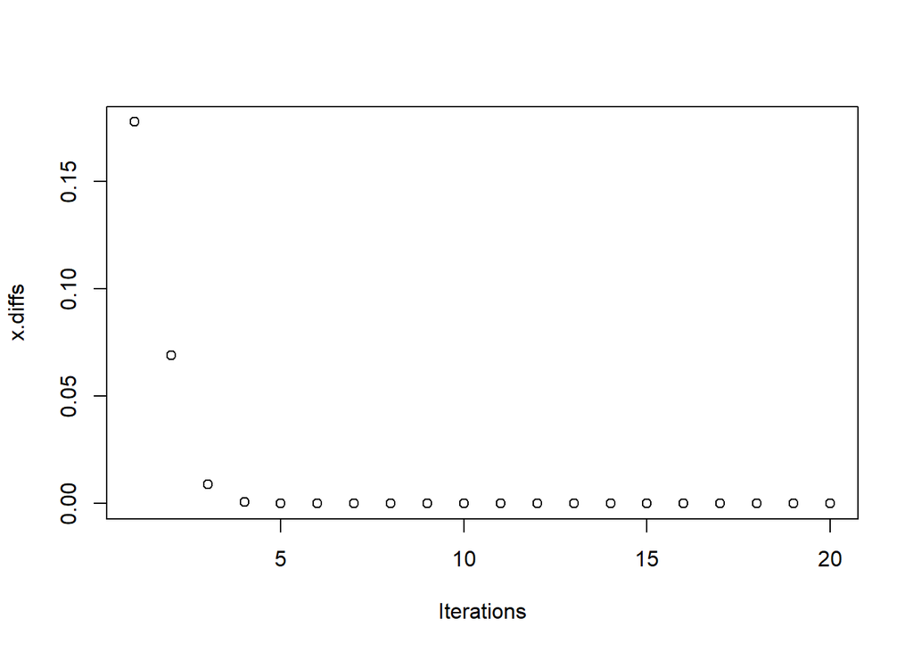

```
##  [1] 0.11889104 0.07517730 0.05512573 0.05802708 0.05802708 0.04545455
##  [7] 0.04545455 0.04545455 0.04545455 0.04545455 0.10058027
```

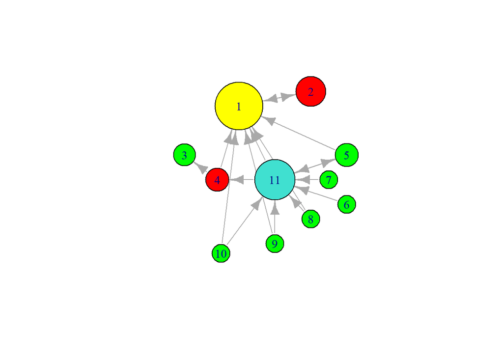

```
## [1] "alpha = 0.7"
```

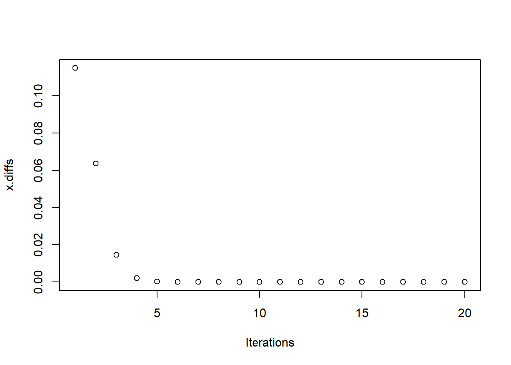

```
##  [1] 0.10011901 0.06231438 0.03669378 0.04037596 0.04037596 0.02727273
##  [7] 0.02727273 0.02727273 0.02727273 0.02727273 0.07487560
```

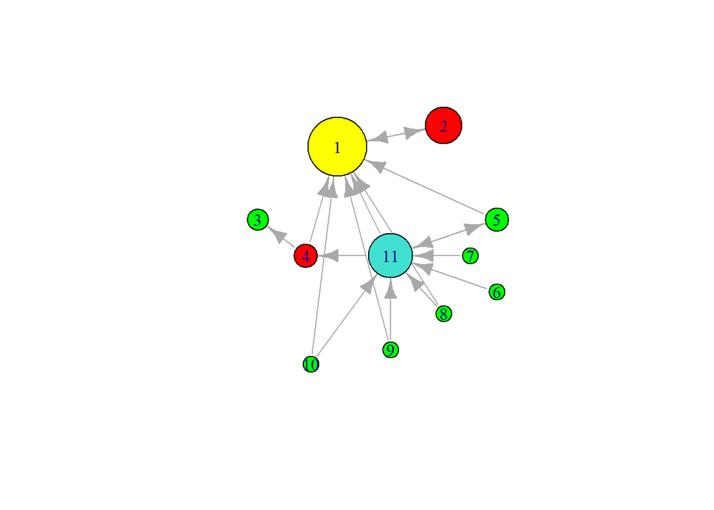

```r
A <- init.graph()
G <- graph.adjacency(A)
# Add self loops
M <- A + diag(rep(1, 11))

for (alpha in c(0.1, 0.5, 0.7)) {
  print(paste('alpha =', alpha))
  x <- page.rank(n.iter = 20, alpha, M, G, draw.convergence = TRUE)
  print(x)
  plot(G, vertex.size = x*5e2, vertex.color=smileycolors, layout=l)
}
```

3 values of alpha are tested above: 0.1, 0.5 and 0.7. By the drawn graphs, a small alpha doesn’t differentiate the nodes much because the characteristics of each node don’t matter as much. As alpha increases, nodes are differentiated more and more until, as also shown in exercise 3, the big nodes start getting smaller too.

In addition to the drawn graphs, a plot has been generated for each alpha: the difference between the nodes’ scores throughout the iterations of the page rank algorithm. The difference measured here is $\sqrt{\sum_{j = 1}^{k}({x_j - x_{old_j}})^2}$, where *k* is the number of nodes.

## Exercise 5

The time complexity of the function *update(x)* is $O(n^2)$.

It could be improved by only accessing each node’s neighbors rather than checking every possible pair of nodes. The graph’s data structure would have to be changed from an adjacency matrix to another such as an adjacency list, which would change the time complexity of *update(x)* to $O(n*m)$, where *m* is the number of edges reaching a particular node. The sparser a graph is, the lower this time complexity, unlike the one of the original *update(x)* the time which stays independent of the edges.